# Figure

```python
import matplotlib.pyplot as plt
import numpy as np
```

Một **figure** như ta thường thấy là một đối tượng của **lớp figure** trong thư viện **matplotlib**. **Lớp figure** được định nghĩa trong module matplotlib.figure, lớp này chứa tất cả những thành phần của một hình vẽ (top level container for all plot elements). Tức là mọi thuộc tính, phương thức của hình vẽ đều được định nghĩa trong lớp này.

Để khởi tạo một **figure trống**, ta chỉ đơn giản gọi phương thức **.figure()** của **plt**

**Khởi tạo figure trống:**

`fig = plt.figure()`

**Gọi phương thức show() của pyplot để hiện figure hiện tại:**

`plt.show()`

Sau khi khởi tạo, **fig** chỉ là một **reference** đến một đối tượng thực sự trên RAM. Để xuất hiện cửa sổ **figure**, thông thường ta gọi lệnh **plt.show()**:

```python
fig = plt.figure()
plt.show()
```

Như vậy, về mặt trực quan thì **figure** là cái cửa sổ chứa tất cả những gì ta sẽ vẽ trên đó.

# Thành phần chính của một figure:

Thành phần chính của một **figure** là các **axes** (những khung nhỏ hơn để vẽ hình lên đó). Một **figure** có thể chứa một hoặc nhiều **axes** . Nói cách khác, **figure** chỉ là khung chứa, chính các **axes** mới thật sự là nơi các hình vẽ được vẽ lên.

Theo ngôn ngữ đối tượng thì: **figure** có một thuộc tính kiểu **list** gọi là **axes**. Danh sách này chứa các **axes** của **figure** đó. Mỗi **axes** là một đối tượng của **lớp Axes** (lớp này được định nghĩa trong module matplotlib.axes). Mỗi **axes** có thể chứa một hoặc nhiều **hình vẽ (plots)**.

Như vậy, các phần tử như: **đường vẽ (plots)**, các **điểm chia (ticks)**, **tên của các trục tọa độ (xlabel, ylabel)**,… đều là con của **axes** chứ không phải là của **figure**. Vì thế, sẽ không có những **methods** gọi từ **figure** kiểu như:

- fig.plot()
- fig.get_xlabel()
- fig.set_xticks()
- …

**Ví dụ của một figure có nhiều axes chồng chéo nhau:**

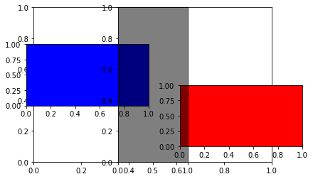

```python
# Khởi tạo một figure trống
fig1 = plt.figure(u'Các axes chồng chéo nhau trong một figure')

# Thêm axes bằng lệnh add_subplot
fig1.add_subplot(1,1,1, facecolor='white')

# Thêm axes bằng lệnh add_axes
fig1.add_axes([0.1, 0.4, 0.4, 0.3], facecolor=(0,0,1))
fig1.add_axes([0.6, 0.2, 0.4, 0.3], facecolor='#ff0000')

# Thêm tiếp một axes bằng lệnh add_subplot
# Viết tắt của fig1.add_subplot(1,3,2):
fig1.add_subplot(132, facecolor=(0,0,0,0.5))

# Hiện hình vẽ lên
# fig1.show()
```

Trong thực tế không ai bố trí các **axes** như vậy. Ví dụ trên chỉ cho thấy: một **figure** có thể có bao nhiêu **axes** tùy thích, có thể **thêm-xóa-sửa** các **axes** bất kỳ lúc nào vì chúng là các **đối tượng độc lập** (chúng ta để ý thấy trong mỗi **axes**, các trục tọa độ luôn là từ 0 đến 1).

# Quản lí các axes trong figure

Tất cả các **axes** của **figure** đều được liệt kê trong **fig1.axes** (ở ví dụ trên), nhưng danh sách này là **Read-only**. Vì thế để lấy danh sách các **axes** và thay đổi chúng, ta phải dùng phương thức **get_axes()** của fig1 (điều này không có gì lạ nếu đã có kinh nghiệm với OOP).

Giả sử bây giờ muốn bỏ hết các điểm chia tọa độ đi, thêm vào mỗi axes dòng chữ “TEXmath” ở góc dưới bên trái. Chỉ cần dùng vòng lặp for như sau:

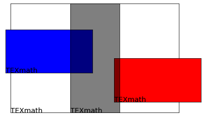

```python
# Khởi tạo một figure trống
fig1 = plt.figure(u'Các axes chồng chéo nhau trong một figure')

# Thêm axes bằng lệnh add_subplot
fig1.add_subplot(1,1,1, facecolor='white')

# Thêm axes bằng lệnh add_axes
fig1.add_axes([0.1, 0.4, 0.4, 0.3], facecolor=(0,0,1))
fig1.add_axes([0.6, 0.2, 0.4, 0.3], facecolor='#ff0000')

# Thêm tiếp một axes bằng lệnh add_subplot
# Viết tắt của fig1.add_subplot(1,3,2):
fig1.add_subplot(132, facecolor=(0,0,0,0.5))

for ax in fig1.get_axes():
    ax.set_alpha(0.5)
    ax.set_xticks([ ])
    ax.set_yticks([ ])
    ax.text(0,0,"TEXmath", {'fontsize':14})
```

# Figure size

Thuộc tính này quy định kích thước cửa sổ figure (theo đơn vị inch)

```python
fig = plt.figure( figsize = (8, 4), dpi = 100 )
```

Các đối số tương tự cũng có thể được truyền cho các **layout managers**, chẳng hạn như hàm `subplots`:

```python
x = np.linspace(0, 5, 11)
y = x ** 2
```

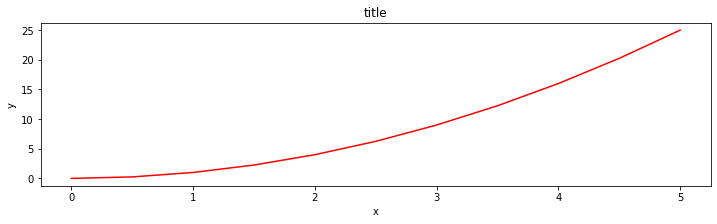

```python
fig, axes = plt.subplots(figsize = (12, 3))

axes.plot(x, y, 'r')
axes.set_xlabel('x')
axes.set_ylabel('y')
axes.set_title('title')
```

# Một số thuộc tính khác:

- `edgecolor` quy định màu của khung viền bao quanh tất cả các **axes** trong **figure** đó
- `linewidth` quy định độ dày của khung viền này
- `facecolor` quy định màu nền của **figure**

# Lưu figure

Để lưu một figure ta dùng **phương thức savefig( )** trong **lớp Figure**:

```python
fig.savefig("Hello.png")
```

Ta được một file ảnh Hello.png:

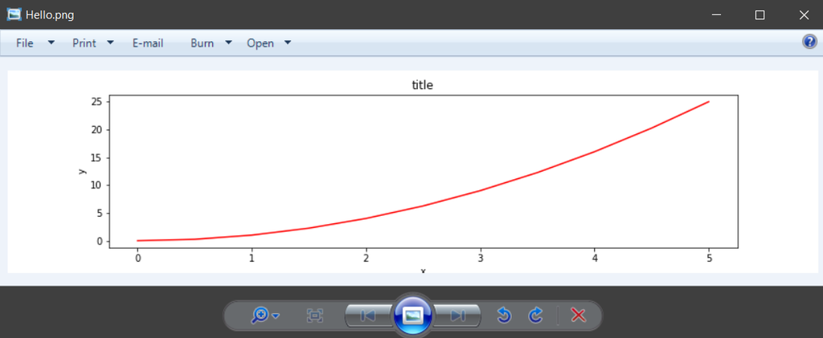

**Chúng ta có thể tùy chọn chỉ định DPI và các định dạng đầu ra khác nhau (PNG, JPG, EPS, SVG, PGF and PDF):**

```python
fig.savefig("Hello2.png", dpi = 640)
```

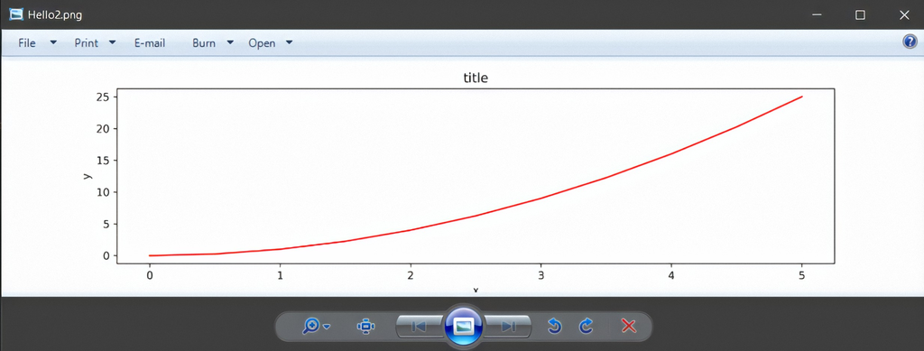

**Một số lưu ý khi sử dụng.**

Giả sử ta vẽ hình sau đây trên một **figure** có nền màu xám như sau:

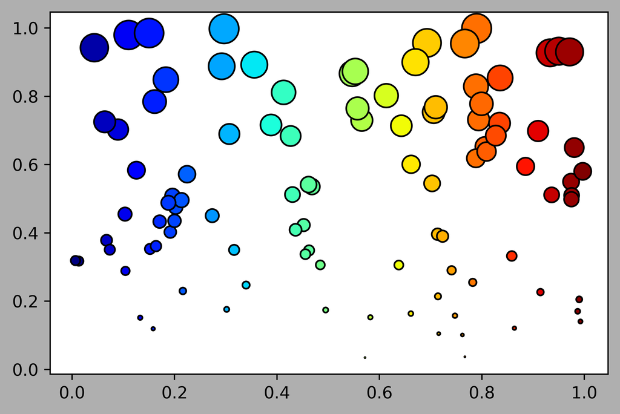

```python
# Khởi tạo hai mảng ngẫu nhiên X và Y
n = 100
X = np.random.rand(n)
Y = np.random.rand(n)

# Diện tích sẽ tăng dần theo trục Y
area = 100 * Y**2 * np.pi

# Màu sắc sẽ thay đổi theo trục X
colors = X

# Khởi tạo một figure trống có nền xám
fig = plt.figure(facecolor='#00000050', dpi = 640)

# Gọi phương thức gca() (get curent axes) của fig
# Sau đó vẽ lên axes nhận được
fig.gca().scatter(X, Y, s=area, c=colors, cmap=plt.cm.jet, edgecolor='k')
# fig.show()
```

Phương thức **gca()** dùng để gọi đến **axes** đang ở trạng thái active trong **figure**. Nếu **figure** chưa có **axes** nào thì **gca()** sẽ tạo ra một **axes** mới, tương đương với **add_subplot(111)**

Bây giờ thử lưu **figure** trên bằng lệnh **fig.savefig('random points.png')**. Ta sẽ thu được PNG sau:

```python
fig.savefig('random points.png', dpi = 360)
```

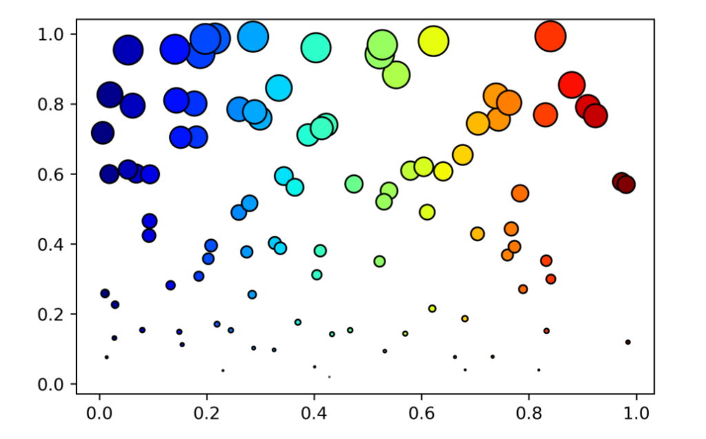

Nền xám của **figure** đã bị biến thành màu trắng. Nguyên nhân là **method savefig()** cũng có tham số **facecolor** (mặc định màu trắng) và tham số này đã over-ride (đè lên) **facecolor** của **figure**.

Để lưu được **figure** đúng như ta nhìn thấy trên cửa sổ **figure** ta phải lấy **facecolor** của **figure** bằng phương thức **get_facecolor()**, tương tự như sau:

```python
fig.savefig('random points.png', facecolor=fig.get_facecolor(), dpi = 360)
```

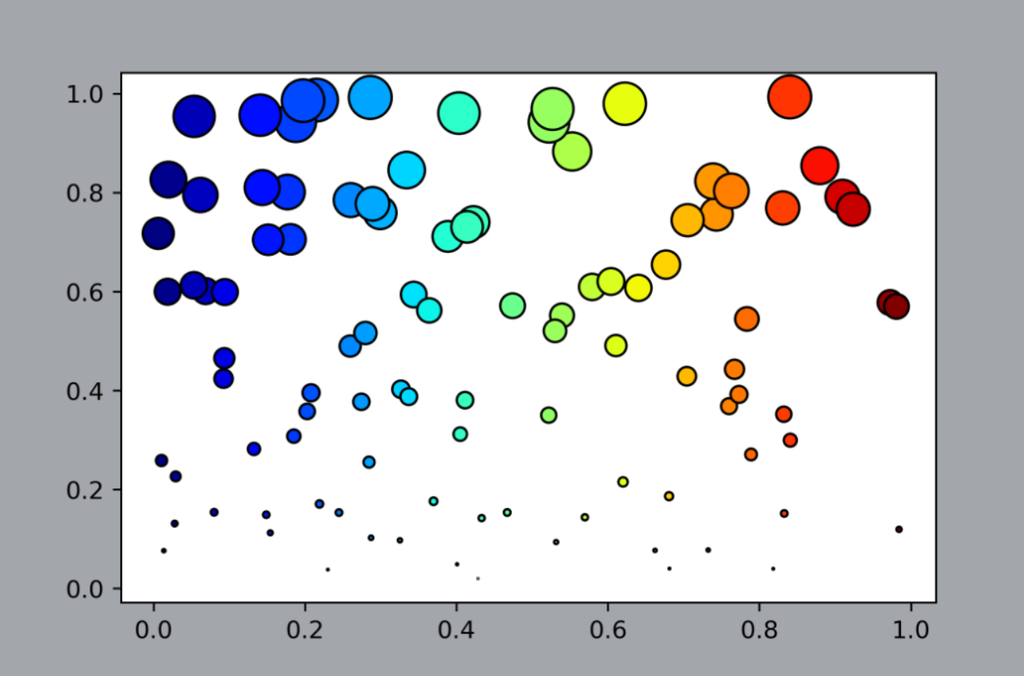

Tương tự, các tham số **edgecolor, dpi …** cũng phải được khai báo trong lệnh **savefig** để giữ đúng nguyên trạng của **figure.**

```python
fig.savefig('random points.png',
            facecolor=fig.get_facecolor(),
            edgecolor=fig.get_edgecolor(),
            dpi = fig.get_dpi())
```

[figure not shown]

**Note:** Sau khi show hình lên, nếu ta zoom hình, co dãn cửa sổ, di chuyển hình vẽ (bằng công cụ move),… thì những tác động này cũng trực tiếp làm thay đổi figure (tức là ta thấy figure thế nào thì sau khi savefig ta cũng sẽ được như thế đó). Do đó, nếu bạn có rất nhiều figure, để căn chỉnh các figure này cho thống nhất, ta không nên căn chỉnh bằng tay. Mà phải căn chỉnh thông qua các tham số khi khởi tạo và khi lưu figure.

# Xóa nội dung một figure

Xóa nội dung của một **figure** tức là xóa đi các **axes** và hình vẽ gắn liền với các **axes** đó. Việc này là cần thiết trong một số trường hợp, thay vì phải khởi tạo ra **figure** mới để vẽ lên.

Có 3 cách để xóa nội dung của một figure. Giả sử ta cần xóa nội dung của fig:

- `fig.clf()`
- `clear()`
- `plt.clf()`

Cách thứ nhất và thứ hai là hoàn toàn giống nhau, vì thực chất phương thức **clear()** sẽ gọi đến **clf()**. Cách thứ 3 chỉ có tác dụng khi **fig** đang **active**

# Một số ý quan trọng trong bài:

- **Figure** là đối tượng của python. Về mặt trực quan thì một **figure** là một cửa sổ chứa các hình vẽ,
- **Figure** có một hoặc nhiều **axes** – nơi thực sự các hình vẽ được “gắn” lên
- Để lấy danh sách các **axes** của **figure**, ta gọi phương thức **get_axes()** từ đối tượng **figure**
- Khi lưu hình vẽ bằng phương thức **savefig**, phải chú ý việc **over-ride** các thuộc tính của **figure*
- **Figure** cho phép xóa các **axes** thuộc về nó bằng phương thức **clear()**